# 218Y_A1

Daphne Jacobsberg with Lena Bakalain and Catherine Beck

1/14/2022

##### General views on the proposed Opportunity to Purchase Act (OPA) in East Palo Alto: There is good intent behind the policy and positive motivation can be justified by constantly increasing real estate prices in East Palo Alto and therefore, increasing the burden of living cost for residents. That said, there is no policy that will ever benefit everyone. It is up to residents, home-owners and renters, and officials to come together to understand which parts of this proposed OPA would be more beneficial than it would be harmful. Other cities in which OPAs have been implemented are an important source of learning that brings great value. Both sides should make use of these case studies to inform their opinions. It is clear that the two main points of friction are single-family homes, which are being included in EPA but other cities have shown to not be a fruitful experiment, and non-profits are potential buyers as home-owners believe this would add an extra layer of complexity and bureaucracy. Some of the main concerns include limiting the free market, significantly prolonging the sale process and driving away investors. Solutions proposed by anti-OPA groups are mostly vague and in my opinion, not entirely thought through. More time should be dedicated towards exploring alternatives and measuring their risks and benefits too.

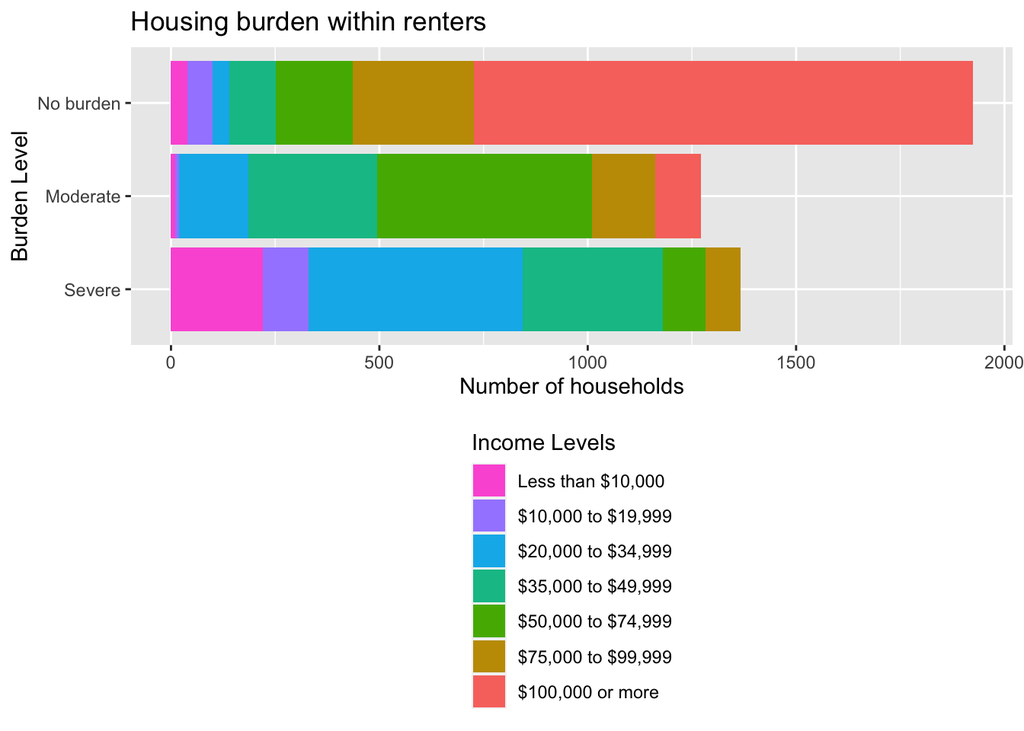

[interactive chart not shown]

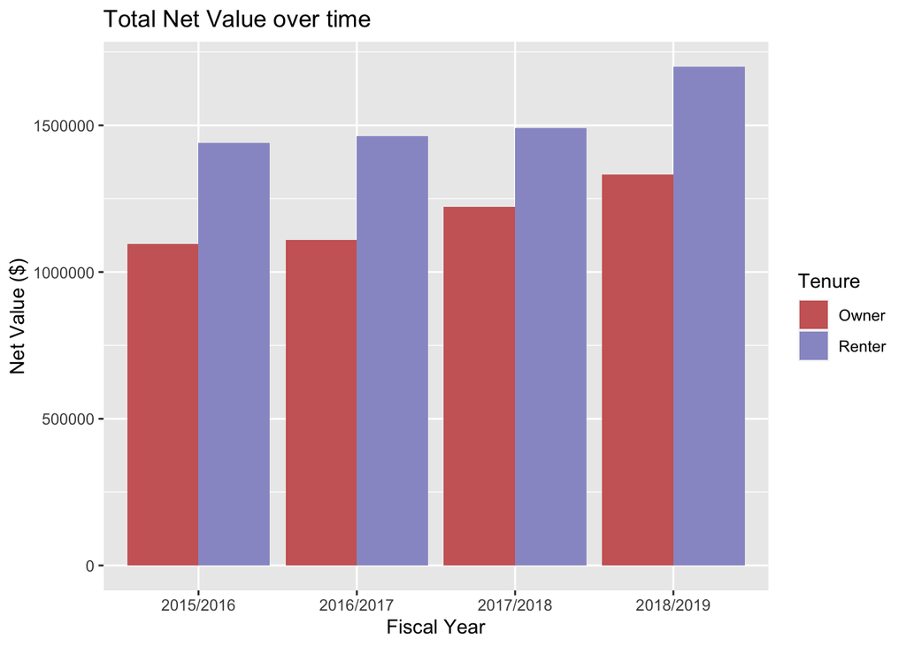

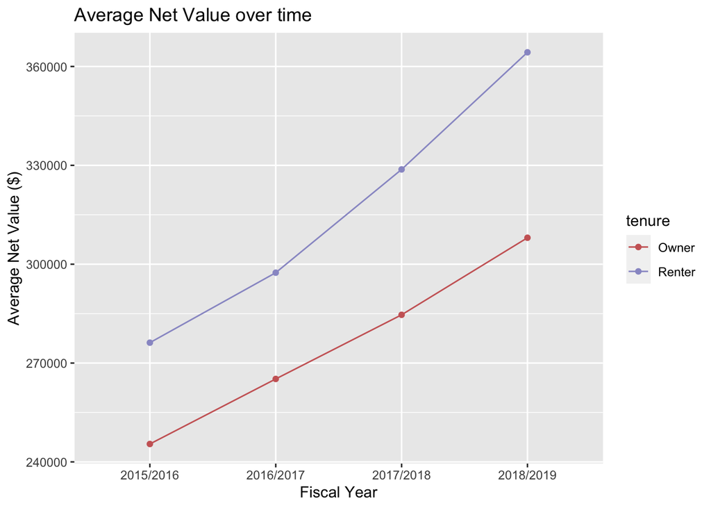

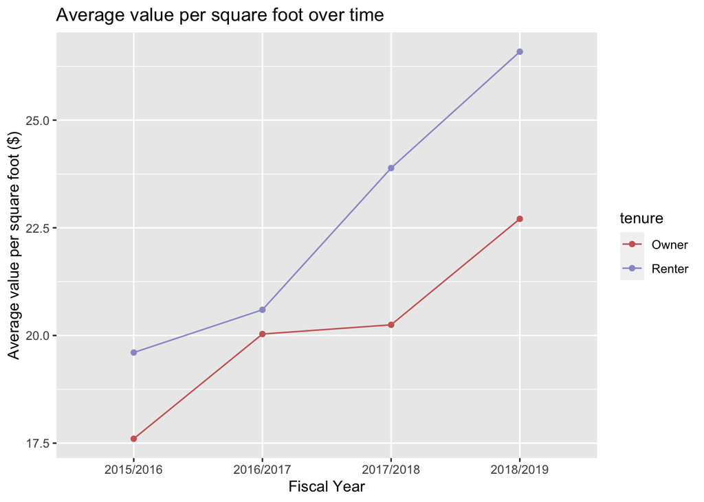